# E-Cigarette and Youth

Shengjie Sun(ss5593) & Chen Chen(cc4317)

4/30/2019

# I. Introduction

We have deployed our blog at: https://stoic-dijkstra-eadb48.netlify.com/2019/04/30/electronic-cigarette-and-youth/

You can open this link directly to have a better reading experience.

## E-cigarette Basics

E-cigarettes are devices that heat a liquid into an aerosol that the user inhales. The liquid usually has nicotine and flavoring in it and other additives. E-cigarettes are considered tobacco products because most of them contain nicotine, which comes from tobacco. Also known as e-cigarettes, e-cigs, electronic nicotine delivery systems, vaporizer cigarettes, and vape pens, they are marketed as a way to stop or cut down on smoking. It aims to provide a similar sensation to inhaling tobacco smoke, without the smoke.

## E-cigarette and Youth

E-cigarettes are very popular with young people. Their use has grown dramatically in the last eight years. Today, more high school students use e-cigarettes than regular cigarettes. The use of e-cigarettes is higher among high school students than adults according to the National Youth Tobacco Survey.

## Goal of This Blog

There is a lot of voice that e-cigarettes are harmful to the youth but they also admit that report that e-cigarettes are more and more popular among youth. In this blog, we will not argue that whether or not the e-cigarette is a good thing as, reported by some articles, it may help reduce the consumption of traditional cigarettes and the traditional cigarettes are far more harmful than electronic ones.

In this blog, we will focus on the true distribution of the usage of e-cigarettes among youth. And pay great attention to the reason for choosing e-cigarettes. By doing this, we found that prohibiting e-cigarettes by telling them e-cigarettes are harmful is not effective!

# II. Description of the data source

We mainly collect row data from `Centers for Disease Control and Prevention` and the link is https://www.cdc.gov/tobacco/data_statistics/surveys/nyts/data/index.html.

Data are available in SAS, Microsoft Access, and Microsoft Excel formats, as well as PDFs of the questionnaire, codebook, and methodology report.

The datasets reveal the smoking and tobacco usage among youth and collected by doing a survey called `National Youth Tobacco Survey (NYTS)`. Data from 1999 and 2018 are available but we only choose those done from 2011 to 2018 because the topics related to electronic cigarette only appear in the above range. The dataset for a particular year, say 2018 looks like following:

|  | Q6 | Q7 | Q8 | Q9 | Q10 | Q11 |
| --- | --- | --- | --- | --- | --- | --- |
| 1 | 4 | 2 | 01 | 1 | 1 | 1 |
| 2 | 4 | 2 | 01 | 1 | 1 | 1 |
| 3 | 4 | 2 | 01 | 1 | 1 | 1 |
| 4 | 2 | 2 | 01 | 1 | 1 | 1 |
| 5 | 1 | 2 | 01 | 1 | 1 | 1 |
| 6 | 4 | 1 | 06 | 2 | 7 | 1 |
| 7 | 3 | 2 | 01 | 1 | 1 | 1 |
| 8 | 4 | 1 | 02 | 1 | 8 | 1 |
| 9 | 4 | 2 | 01 | 1 | 1 | 1 |
| 10 | 2 | 2 | 01 | 1 | 1 | 1 |

[output cut: 10 more lines]

The biggest problem for us is that the questionnaires are different from year to year and we need to go through every questionnaire each year and select the questions that:

1. related to electronic cigarettes,
2. appear at least four years,
3. high quality and can reveal some “truth”.

We divided all the questions related to e-cigarettes into indirectly related and directly related based on whether the words such as “e-cigarettes”, “vape”, etc appear in questions or not. If those words only appear as options or selections, we marked them as indirectly.

It is quite clear that the number of questions, especially those directly related ones, leaps from 2013 to 2014 and goes to peak in 2016. It’s may worth to mention that the questionnaire of 2017 and 2018 are the same.

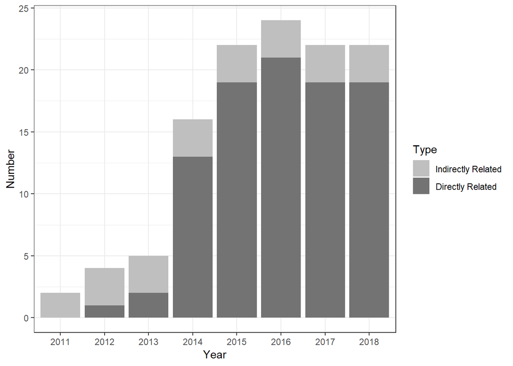

Before 2011, there is no question related to e-cigarettes/vapes, and during 2011, 2012 and 2013, e-cigarettes and vapes are just mentioned not very directly. From 2014 to 2016, great attention was paid while the questions vary from year to year. Starting from 2017, the questions related to e-cigarettes keep same.

All the questions selected are posted in another blog called `All National Youth Tobacco Survey Questions Related to Electronic Cigarette` feel free to check it.

# III. Description of data import / cleaning / transformation

The criteria/requirements say we can not include codes in this blog, but indeed for this part, it is more efficient to explain combined with codes. Anyway, the data were downloaded in a csv file and imported with `readr::read_csv()` smoothly. Some `NA` is filtered and some questions with multiple responses stored in several in columns are combined together. Some responses are low quality and useless, for example, some students may choose “I have never used e-cigarettes” and “I used e-cigarettes in the last 30 days” at the same time. If you want to check the codes, we also posted them in the third blog, feel free to check that!.

# IV. Analysis of missing values

Again, missing value is a very little thing in our datasets and the dimension of our data is huge. There is meaningless to show the pattern of missing values. Also, the package used to show NA seems not to work well in the newest version of R, we will not bother you and us to show this part.

# V. Results

## Trends and Patterns of the Usage of E-cigarettes

One thing we are interested in is how likely people become “addictive” after they try e-cigarettes once or twice and become regular smokers. We define “addictive” and “regular smokers” as those who spend more than two days to smoke e-cigarettes within 30 days. This question is addressed in two steps: 1) what is the percentage of regular smokers in the whole population? 2) what is the percentage of regular smokers among those who tried to smoke once or twice? That is, how likely that people become “addictive” after they have a try to e-cigarettes? And in order to give our readers a direct impression about the extent of addiction, we compare with the data of ordinary cigarettes. The results are shown in the following several figures.

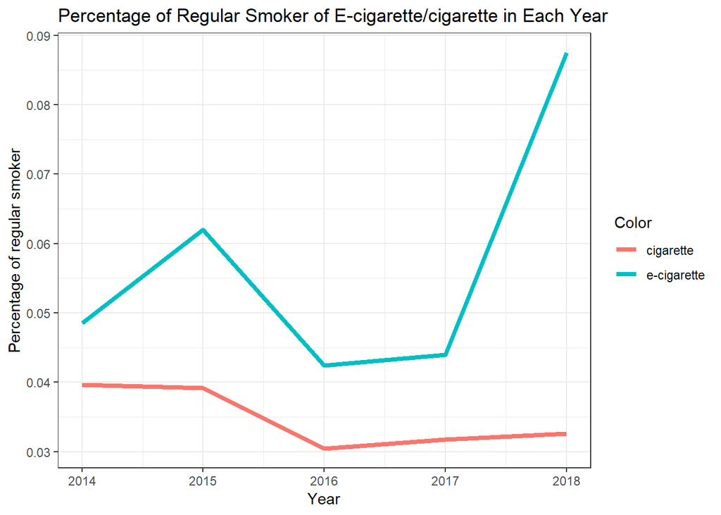

The lines in the figure answer the first question, showing above shows that there about 4.5% to 9% regular e-cigarettes users in the youth, compared to 3% to 4% regular cigarettes smokers in the youth. This result is probably contradictory to our common sense: there are more cigarettes smokers around us than e-cigarettes smokers. Our common sense may be true for adults, however, it is a different story in the youth group. E-cigarettes are more popular in the youth group.

Another thing that worths to notices are that the percentage of regular e-cigarettes smokers is generally increasing while the percentage of cigarettes is generally decreasing, suggesting e-cigarettes are becoming a trend among youth.

In addition to the investigations in the whole youth population, gender is also considered as an important factor: we would like to find out whether there is a huge difference between different genders with respect to smoking. Here is the result:

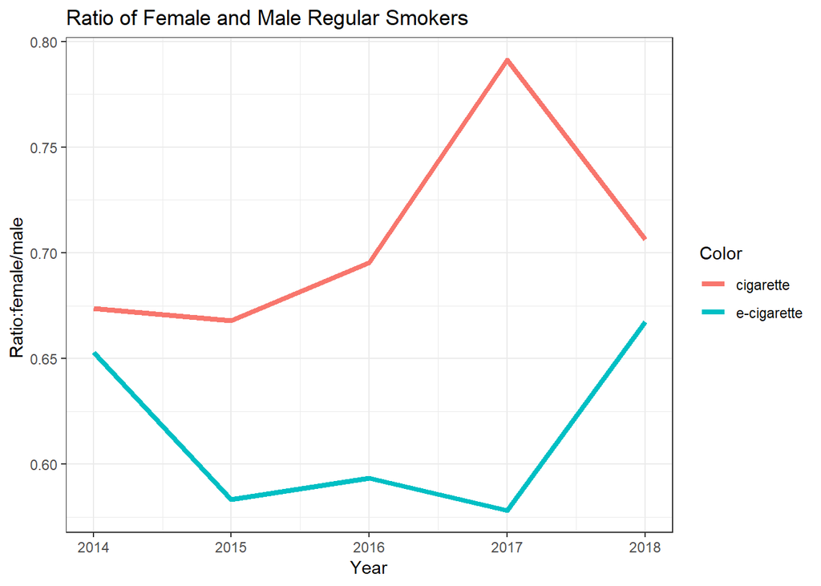

It seems that males are more “fashionable” in regards to smoking. There is a higher female percentage in traditional smoking than in the new-born e-cigarettes smoking.

To answer the second question, we plot the percentage of regular smokers among those who tried to smoke once or twice. The higher the percentage is, the more likely people sink into it.

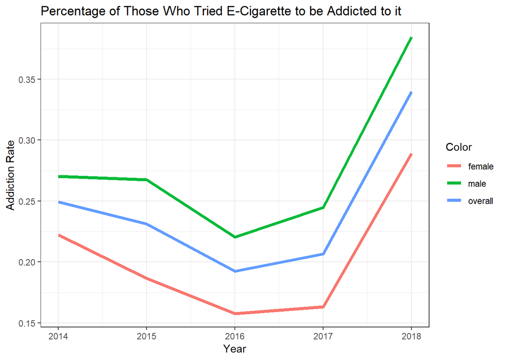

The figure above shows that 25% of those who are willing to try e-cigarettes turn out to be regular smokers. The explanation for this can be multiple: it is possible that in the beginning 1/4 of the tiers are determined to be regular smokers. Or it is possible that e-cigarettes can attract 1/4 of the triers. Gender also plays a role in the process. Female are less likely to turn into a regular e-cigarette smoker than males.

### Age

As previously shown, e-cigarettes seem to become more and more popular among young people. Not only is it reflected in the percentage of regular smokers, but also reflected in the age when people try e-cigarettes for the first time.

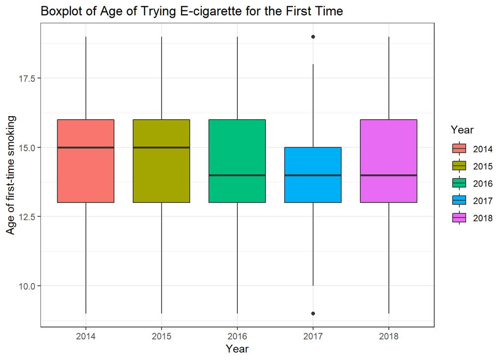

The figure above shows that the age when the youth try their first taste of e-cigarettes becomes younger. In the investigation in 2014, it happened at the age of 15. Now in 2018, it happens at the age of 14.

### Days

One one hand, we see the popularity of e-cigarettes among youth. On the other hand, the days that people spend to use e-cigarettes is increasing. We suspect it is partially due to the popularity of e-cigarettes. One possibility is that when people realize e-cigarette is a fashionable thing, they may have less motive to restrain themselves from it. Another reason we can think of is that people with more years of smoking experience tend to smoke more often. E-cigarettes is a new thing, so the percentage of many-year smokers is still increasing.

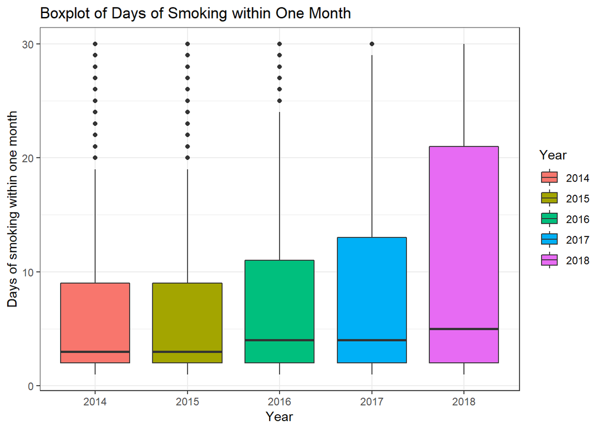

The figure above shows that in 2014, the average days that people spend on smoking was 3 days. Afterwards, it gradually increases to 5 days in 2018. The increase of the number of smokers with the middle level of addiction or even higher is more obvious, though it is masked by the majority with low-level addiction.

### Advertisement

The questionnaire includes questions about advertisement in four kinds of media: internet, newspaper, supermarkets, TV. It asks how often do youth see the advertisement of e-cigarette in those media. Five options are given: never, rarely, sometimes, most of the time, always.

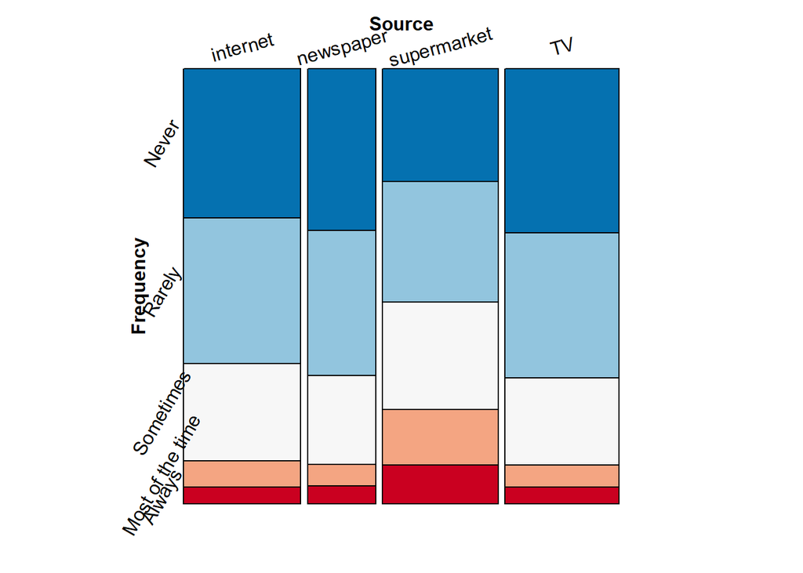

From the figure above, we are able to conclude that fewer advertisements are put in the newspaper. Relatively more ads are put on the internet, supermarket, and TV. It is possible because less and fewer people read newspapers. It looks like it is more often to see the advertisement of e-cigarettes in the supermarket. Though youth may show up on the internet more often, the supermarket is the main battleground for an e-cigarette to win customers. One explanation is that people with purchasing power are more likely to go to the supermarket, and the manufacturer wants to win over those potential clients.

## Analysis

### Attitudes of E-cigarettes

We combined the following five questions together:

Q27. Have you ever been curious about using an e-cigarette?

The response of the questions are shown by the color in legend `Type`, The red lines indicates the response of those who are curious about e-cigarettes and the blue/green lines shows those of not curious.

Q35. Do you think that you will try an e-cigarette soon?

Q36. Do you think you will use an e-cigarette in the next year?

Q37. If one of your best friends were to offer you an e-cigarette, would you use it?

Q3. What grade are you in?

Due to the limitation of `GGally::ggparcoord()`, only 2000 response can plot at one time. Therefore we sampled 2000 response randomly and the following patterns/findings are nearly repeated every time.

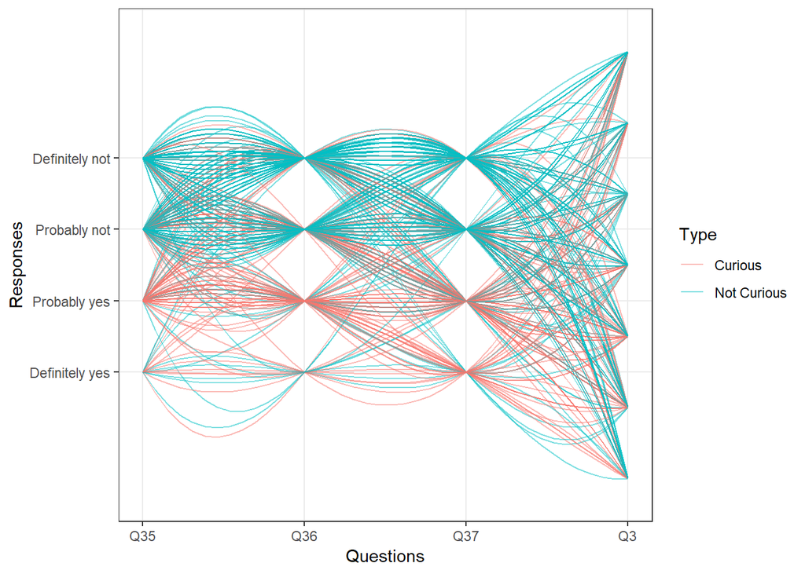

The most obvious pattern is whether youth are curious about the e-cigarettes almost determines whether they will try e-cigarettes.

If we exam the pictures more carefully, we can see the effects of friends. The lines across `Probably yes` and `Definitely yes` from `Q37` are denser than those from `Q35` and `Q36`. This indicates a little bit of the reasons why youth use e-cigarettes. If you can not see clearly due to the bad representation of the samples, never mind, we will study this more thoroughly in the following parts.

### What are the reasons youths have used e-cigarettes? (Select one or more)

A. I have never tried an e-cigarette

B. Friend or family member used them

C. To try to quit using other tobacco products, such as cigarettes

D. They cost less than other tobacco products, such as cigarettes

E. They are easier to get than other tobacco products, such as cigarettes

F. Famous people on TV or in movies use them

G. They are less harmful than other forms of tobacco, such as cigarettes

H. They are available in flavors, such as mint, candy, fruit, or chocolate

I. They can be used in areas where other tobacco products, such as cigarettes, are not allowed

J. I used them for some other reason

As indicated in the subtitles, this is a question with several responses. Generally, this kind of data is very difficult to visualize. We will exam this data step by step.

First, we clean the data a little bit and create a new column called `Q33` showing the response in a human reading way. And the filter `Q33A` as we only care about those have tried e-cigarettes.

```
## # A tibble: 7 x 10
##   Q33B  Q33C  Q33D  Q33E  Q33F  Q33G  Q33H  Q33I  Q33J  Q33
##   <chr> <chr> <chr> <chr> <chr> <chr> <chr> <chr> <chr> <chr>
## 1 B     <NA>  <NA>  <NA>  <NA>  <NA>  <NA>  <NA>  <NA>  B
## 2 <NA>  <NA>  <NA>  <NA>  <NA>  G     H     <NA>  J     GHJ
## 3 B     <NA>  <NA>  <NA>  <NA>  <NA>  H     <NA>  <NA>  BH
## 4 B     <NA>  <NA>  <NA>  <NA>  <NA>  <NA>  <NA>  <NA>  B
## 5 <NA>  <NA>  <NA>  <NA>  <NA>  G     <NA>  <NA>  <NA>  G
## 6 <NA>  <NA>  <NA>  <NA>  <NA>  <NA>  <NA>  <NA>  J     J
## 7 B     <NA>  <NA>  <NA>  <NA>  <NA>  <NA>  <NA>  <NA>  B
```

You know what? There are totally 159 different combination appears! But mathematically speaking, there could be 512 different choices at most. So, definitely, there are some patterns behind.

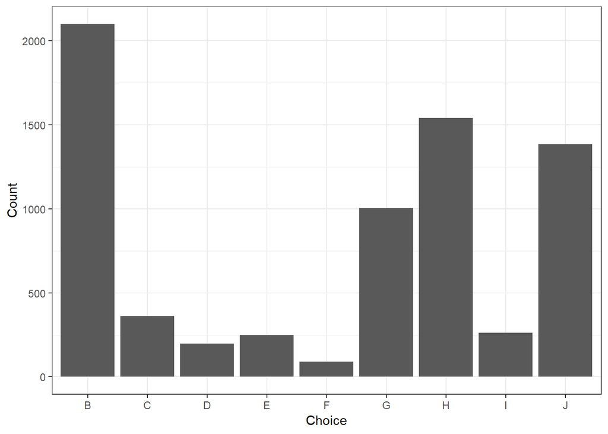

In the above plot, we only count the frequency of each choice without considering the combination. It is quite clear that choice B: Friend or family member used them is the major reasons for youth to try e-cigarettes. And the second is e-cigarettes are available in flavors, such as mint, candy, fruit, or chocolate. And then they are less harmful than other forms of tobacco, such as cigarettes if we do not consider other reasons, i.e. choice J. Health is not the major reason for youth to choice e-cigarettes!! And if only counts less than half of the influence of friends and family!!

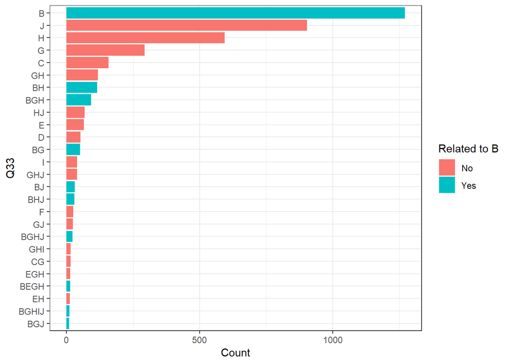

# Interactive component

We have deployed our blog at: https://stoic-dijkstra-eadb48.netlify.com/2019/04/30/electronic-cigarette-and-youth/

Open that link to see the interactive part!!

Our dear reader might also have your own opinion about e-cigarettes, like whether it is harmful, or whether its flavors are fascinating. People with different reasons to try e-cigarettes might end up with a different level of addiction to e-cigarettes. Some might just give it up. Others might become a regular user. Others might be obsessed with it. Different genders might also have different results in regard to the extent of addiction. With the data that we have, a rough estimate to the level of addiction can be given on the basis that you plan to have a try to e-cigarettes of have already had a try to e-cigarettes. Here is the guidance:

1. This is just a rough/recreational estimation based on data from 2018 and 2017, do not be afraid to have a try!!
2. Choose your opinion about e-cigarettes. You can check multiple options.
3. Look up the barplot. There are 7 groups of bars, each of which includes a bar for female (red) and a bar for male (green). The x-axis is the number of days to smoke e-cigarettes within 30 days. That represents the level of addiction to e-cigarettes: the group in the most left side is the group who did not smoke any e-cigarettes during the last 30 days. We can take that as the lowest level of addiction. The group on the most right side is the group who smoke e-cigarettes every day during the past 30 days, which represents the highest level of addiction. Other groups are in between the two extremes. The y-axis represents the percentage to fall into each group. For instance, if you are a female and you choose “famous people in the movie or on TV use them”, you will have 24% probability to fall into the group of “highest addiction”.

[interactive chart not shown]

# Conclusion

## Limitation

1. The number of questionnaires covering e-cigarettes is still small and thus it is not very confidence for us to conclude some trend across the dimension of time.
2. The data from surveys sometimes cannot reflect the real situations as youth may cheating a little bit.
3. We do not do statistical analysis, even though this is not required by the final project. However, getting a conclusion from plots/graphics directly may sometimes very misleading.

## Future Directions

1. Do some statistical analysis to get a more accurate result.
2. Get more data from multiple sources. For example, we may collect the data indicates the consumption of e-cigarette.

## Lessons Learned

1. Actually, we learned for most of the time, the interactive plot is unnecessary. The static plots can demonstrate almost all of the information.
2. Interactive plots need readers to engage in and try some options and then they can find results. It’s more useful if some people want to teach students some complex ideas. However, for most blogs, aiming at conveying some information in a quick and efficient way.
3. In this blog, we use the interactive to visualization a very high dimension and complex data. We think this is a very meaningful usage of interactive plots. Some others’ plot like putting the mouse on some position and then showing related data is totally meaningless in our opinion. And some others’ ‘interactive plot’ is just animations and actually no interaction within them.